# Pacific Salmon SAR & SAS Estimator

Background

This script uses WDFW hatchery coded wire tag (CWT) release and return data to fit run-specific smolt-adult return (SAR) and smolt-adult-survival (SAS) models for Pacific salmon species. The first chunk below loads libraries, sets directories, and sources any functions required for the analysis. A table is generated that displays species- and system-specific location_code information for the parameters set in the YAML header, including hatchery_location_codes, release_location_codes, and stock_location_codes for data to be used in SAR/SAS calculation. This table is based on a metadata ruleset constructed by the developers, and new queries will require additions to this ruleset for smooth data processing and model fitting.

This chunk pulls CWT-based release and recovery data from the Pacific States Marine Fisheries Commission’s (PSMFC) Regional Marking Information System (RMIS) database for the species and hatchery stock set by the user at the top of this script. Release and return data are categorized by release size, release stage, release location, and are uniquely identified by coded-wire-tag codes. The release data are pulled first and length-weight data associated with those releases are used to determine stage-at-release.

To ensure all data employed in SAR/SAS calculations are smolt-release data, the script categorizes releases by stage using a mixture of information reported in the literature and RMIS data queried by the user. Quinn (2018) reports length-at-smolt (mm) by species in Table 15.1, which summarizes data from 218 published and unpublished reports. We use these reported values to inform a release stage designation, where the avg_length and avg_weight fields queried from RMIS by the user are fit to an exponential model and the model fit is used to predict weight-at-smolt. This weight-at-smolt is then used to classify release stages, currently implemented as “smolt” if they are larger than the threshold size calculated or “fry_parr” if smaller than it. Given the query-specific nature of this analysis, if program- or system-specific data on size-at-smolt were available, these data could be used directly to inform release_stage classifications.

After stage has been assigned, release data are filtered for CWT-tagged groups (i.e., tag_code_or_release_id beginning with “!” are removed). An event_released column is created by combining cwt_1st_mark_count and cwt_2nd_mark_count, and julian day is calculated from first_release_date. Release counts (“event_released”) are then aggregated by run, brood year, release location, tag code, julian day, weight-at-release, and stage-at-release. Tag code groups that do not have one of these data types are removed, as well as groups that fall outside the brood year window designated in the YAML header. A table is generated below that reports the release_location_code information for the filtered data.

The CWT tag codes retained in the release data after filtering are then used to iteratively pull recovery data by tag code. The estimated number of recoveries (number_cwt_estimated) is reported by tag_code, so only grouped data are available. These data are aggregated by tag_code and rearing treatments of interest (e.g., size-at-release, release month, release julian day, etc.). Release year and recovery year are used to calculate age-at-recovery, and this age is used to filter the data for adults (e.g., age-3+ in Region 5). Together, these filtered release and recovery data are used to calculate fate-specific SARs below.

**Tab 1**

Table 1: Parameter values set in the YAML header defining which data are being pulled from RMIS for calculation of SAR and SAS.

| params | value |
| --- | --- |
| system | r5_cowlitz |
| species | 1 |
| run | 1 |
| start_yr | 2010 |
| end_yr | 2020 |

**Tab 2**

| species | run | loc_code | loc_col | name | region | system |
| --- | --- | --- | --- | --- | --- | --- |
| 3 | 4 | 3F42001^^260002^H01 | hatchery_location_code | COWLITZ TROUT HATCHERY | 5 | r5_cowlitz |
| 3 | 2 | 3F42001^^260002^H01 | hatchery_location_code | COWLITZ TROUT HATCHERY | 5 | r5_cowlitz |
| 3 | 9 | 3F42001^^260002^H01 | hatchery_location_code | COWLITZ TROUT HATCHERY | 5 | r5_cowlitz |
| 1 | 1 | 3F42001^^260002^H01 | hatchery_location_code | COWLITZ TROUT HATCHERY | 5 | r5_cowlitz |
| 2 | 7 | 3F42001^^260002^H01 | hatchery_location_code | COWLITZ TROUT HATCHERY | 5 | r5_cowlitz |
| 1 | 1 | 3F42001^^260002^H02 | hatchery_location_code | COWLITZ SALMON HATCHERY | 5 | r5_cowlitz |
| 1 | 3 | 3F42001^^260002^H02 | hatchery_location_code | COWLITZ SALMON HATCHERY | 5 | r5_cowlitz |
| 2 | 7 | 3F42001^^260002^H02 | hatchery_location_code | COWLITZ SALMON HATCHERY | 5 | r5_cowlitz |
| 3 | 2 | 3F42001^^260002^H02 | hatchery_location_code | COWLITZ SALMON HATCHERY | 5 | r5_cowlitz |
| 3 | 4 | 3F42001^^260002^H02 | hatchery_location_code | COWLITZ SALMON HATCHERY | 5 | r5_cowlitz |
| 2 | 3 | 3F42001^^260002^H02 | hatchery_location_code | COWLITZ SALMON HATCHERY | 5 | r5_cowlitz |

**Tab 3**

Table 3: Release location information for filtered data used in the following smolt-adult return calculations.

[output not shown]

[interactive chart not shown]

Figure 1: Length-weight relationship used to determine weight-at-smolt via reported lenght-at-smolt (Quinn, 2018). The red-dashed vertical line shows the species-specific size used for the weight-at-smolt conversion. Facets are split by run.

References

Independent Scientific Advisory Board (ISAB). 2025. Challenges and opportunities for improved estimation, interpretation, and use of smolt-to-adult return (SAR) and survival (SAS) metrics for salmon and steelhead in the Columbia River Basin. Report ISAB 2025-1. Northwest Power and Conservation Council, Portland, Oregon.

Quinn, T.P. 2018. The behavior and ecology of Pacific salmon and trout. Second Edition. University of Washington Press. ISBN: 9780295743332.

Smolt-adult-return (SAR)

Smolt-adult-return is calculated for each categorized fate (hatchery, fishery, and spawning ground) of paired release-recovery data. Below, fate is categorized based on fishery coding, and then fate-specific SARs are reported. These fate-specific SARs are then used below to: (1) fit predictive SAR models, and (2) calculate smolt-adult-survival (SAS). Fate is determined by the fishery coding reported for each recovery. Fishery codes range from 10-99, with some additional codes supplied for high seas fishery categories (800-812). We designate troll (10-19), net & seine (20-29), aboriginal (30-39), sport (40-49), treaty subsitence (56), test (60-69), and high seas (80-89, 800, 802-805, 812) fisheries recoveries as ‘fishery’ fates. In addition, we designate hatchery (50), fish trap (52), broodstock collections (53), and mixed broodstock collection/hatchery returns (57) recoveies as ‘hatchery’ fates, and we designate spawning ground (54) recoveries as ‘spawngr’ fates.

[figure not shown]

Figure 2: Smolt-adult return calculated collectively across brood year released and recovery fate.

**Tab 1**

Table 4: Recovery locations associated with a ‘hatchery’ fate in the filtered data, and the number of estimated recoveries (number_cwt_estimated) reported for each recovery location.

| recovery_location_code | name | latitude | longitude | psc_region | number_cwt_estimated |
| --- | --- | --- | --- | --- | --- |
| 3F42001^^260002^H02 | COWLITZ SALMON HATCHERY | 46.5113 | -122.6293 | LOCR | 13295.77 |
| 3F42001^^270168^H | LEWIS RIVER HATCHERY | 45.9370 | -122.6165 | LOCR | 12.02 |
| 3F42001^^270002^H | KALAMA FALLS HATCHERY | 46.0160 | -122.7336 | LOCR | 3.03 |
| 3F42001^^470001^H02 | WELLS HATCHERY | 47.9468 | -119.8706 | UPCR | 1.01 |
| 3F10412^^160005^H | GEORGE ADAMS HATCHERY | 47.3013 | -123.1818 | HOOD | 1.01 |
| 3F42001^^270002^R | KALAMA R 27.0002 | 46.0338 | -122.8746 | LOCR | 1.00 |
| 3F42001^^270339^R | CEDAR CR 27.0339 | 45.9365 | -122.6174 | LOCR | 1.00 |

**Tab 2**

Table 5: Recovery locations associated with a ‘spawngr’ fate in the filtered data, and the number of estimated recoveries (number_cwt_estimated) reported for each recovery location.

| recovery_location_code | name | latitude | longitude | psc_region | number_cwt_estimated |
| --- | --- | --- | --- | --- | --- |
| 3F42001^^260002^R | COWLITZ R 26.0002 | 46.0956 | -122.9155 | LOCR | 219.88 |
| 3F42001^^270002^R | KALAMA R 27.0002 | 46.0338 | -122.8746 | LOCR | 4.07 |

**Tab 3**

Table 6: Recovery locations associated with a ‘fishery’ fate in the filtered data, and the number of estimated recoveries (number_cwt_estimated) reported for each recovery location.

| recovery_location_code | name | latitude | longitude | psc_region | number_cwt_estimated |
| --- | --- | --- | --- | --- | --- |
| 3F42001^^260002^R | COWLITZ R 26.0002 | 46.0956 | -122.9155 | LOCR | 2157.42 |
| 3M32202 | MARINE AREA 2 | NA | NA | GRAY | 620.41 |
| 3M32101 | MARINE AREA 1 | NA | NA | WILP | 216.76 |
| 5F33207^^R7^^^^^13 | YOUNGS BAY NET ZONE 7 | 46.1917 | -123.8833 | LOCR | 170.68 |
| 2MSSVP123BIG^BK^^08 | SWVISPBIG BK(123-8) | 48.6667 | -125.6667 | NA | 163.68 |
| 2MN06P101^^^^^^^000 | NTR P101-000 | NA | NA | NA | 162.36 |
| 3M32404 | MARINE AREA 4 | NA | NA | NWC | 132.98 |
| 2MS02P123^^^^^^^000 | SWTR P123-000 | NA | NA | NA | 91.53 |
| 1M1NW113^41 | AK M 1 NW 113-41 | NA | NA | SEAK | 75.02 |
| 5M2222404O2404^^10 | NEWPORT AREA 4 | 44.6217 | -124.0533 | NOOR | 66.13 |
| 3M32303 | MARINE AREA 3 | NA | NA | NWC | 63.64 |
| 5F33209^^R2^^^^^13 | COL R ZONE 2 NET | NA | NA | LOCR | 60.21 |
| 5F33203^^R110^^^12 | COL R WA SPORT SEC 10 | NA | NA | LOCR | 56.64 |
| 2MS01M403^^^^^^^000 | NWTR M403-000 | NA | NA | NA | 48.37 |
| 2MS5SP124^^^^^^^000 | 5NWCVIS P124-000 | NA | NA | NA | 46.92 |
| 5M2221003O1003^^10 | GARIBALDI AREA 3 | 45.5550 | -123.9083 | NOOR | 44.96 |
| 5M2220202O0202^^10 | ASTORIA AREA 2 | 46.1950 | -123.8500 | NOOR | 44.51 |
| 3M11105^^872465 | SEKIU | NA | NA | JUAN | 39.61 |
| 5F33271^^R71^^^^13 | TONGUE POINT ZONE 71 | NA | NA | LOCR | 37.49 |
| 2MSSVP123 | SWVISPT P123 | NA | NA | NA | 37.29 |
| 5M2220202O0202^^11 | ASTORIA SPORT 2 | 46.1950 | -123.8500 | NOOR | 37.04 |
| 1M2PW212 | AK M 2 PW 212 | NA | NA | CEAK | 34.35 |
| 5F33203^^R209^^^12 | COL R OR SPORT SEC 9 | NA | NA | LOCR | 30.75 |
| 2MS01P127^^^^^^^000 | NWTR P127-000 | NA | NA | NA | 29.39 |
| 2MSSVP121SWIF^BK^02 | SWVISPSWIF BK(121-2) | 48.5667 | -124.9833 | NA | 28.66 |
| 2MS24M19BVICT^BW^03 | 24 M19B VICT BW(19-3) | 48.4211 | -123.3928 | NA | 27.85 |
| 2MS5NP125^^^^^^^000 | 5NWCVIN P125-000 | NA | NA | NA | 24.18 |
| 5F33203^^R108^^^12 | COL R WA SPORT SEC 8 | NA | NA | LOCR | 22.23 |
| 5F33274^^R74^^^^13 | BLIND SLOUGH ZONE 74 | NA | NA | LOCR | 21.42 |
| 5F33203^^R207^^^12 | COL R OR SPORT SEC 7 | NA | NA | LOCR | 21.36 |

[output cut: 110 more lines]

**Tab A**

[figure not shown]

Figure 3: Smolt-adult return calcualted from the raw release and return data across brood years and mean weight release groups.

[figure not shown]

Figure 4: Smolt-adult return calcualted from the raw release and return data across brood years and release month.

[figure not shown]

Figure 5: Smolt-adult return calcualted from the raw release and return data across brood years and release sites.

[figure not shown]

Figure 6: Smolt-adult return calcualted from the raw release and return data across brood years and julian days.

**Tab B**

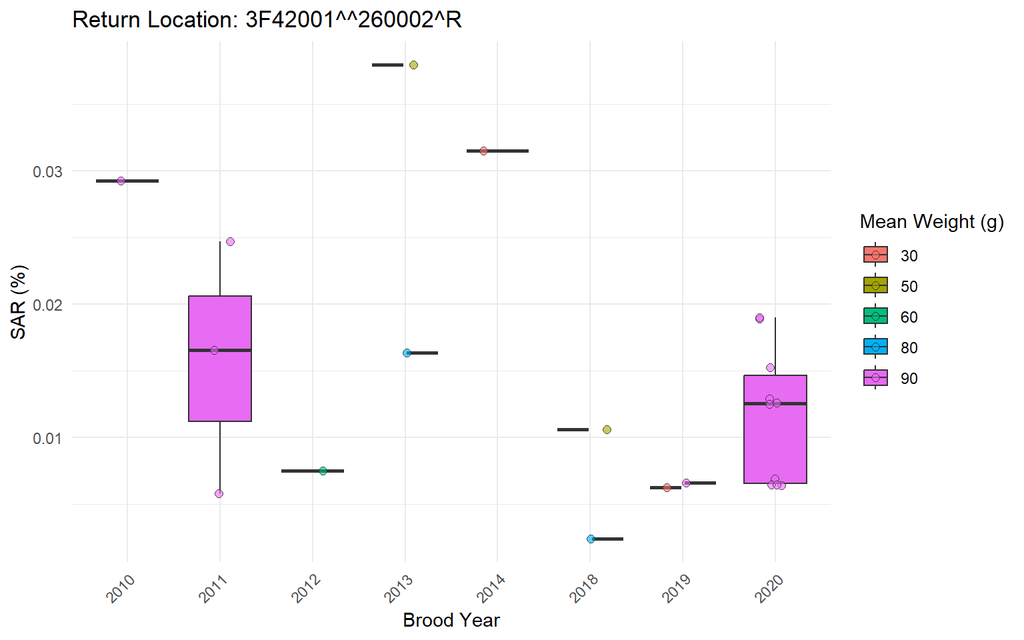

Figure 7: Smolt-adult return calcualted from the raw release and return data across brood years and mean weight release groups.

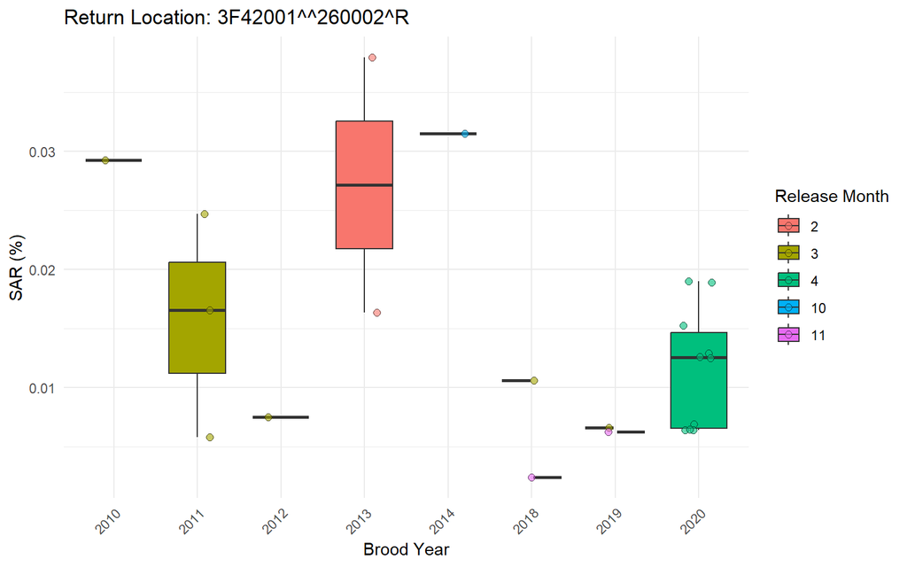

Figure 8: Smolt-adult return calcualted from the raw release and return data across brood years and release month.

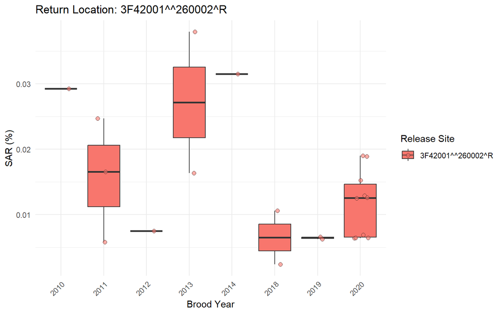

Figure 9: Smolt-adult return calcualted from the raw release and return data across brood years and release sites.

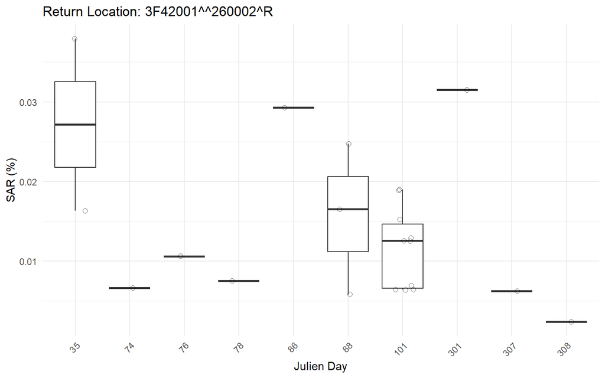

Figure 10: Smolt-adult return calcualted from the raw release and return data across brood years and julian days.

**Tab C**

[figure not shown]

Figure 11: Smolt-adult return calcualted from the raw release and return data across brood years and mean weight release groups.

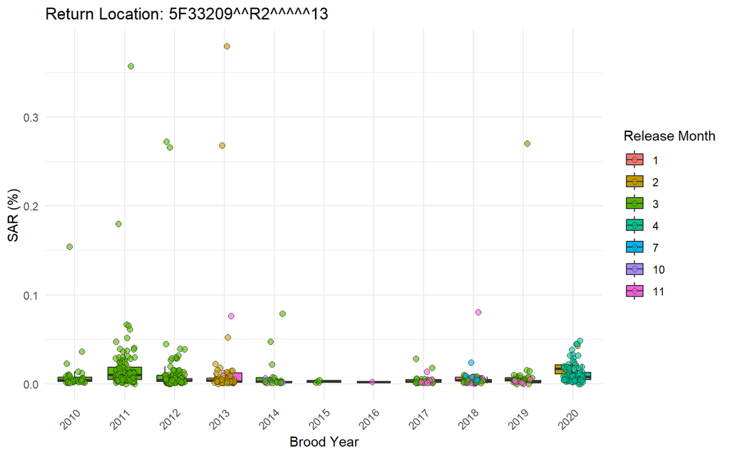

Figure 12: Smolt-adult return calcualted from the raw release and return data across brood years and release month.

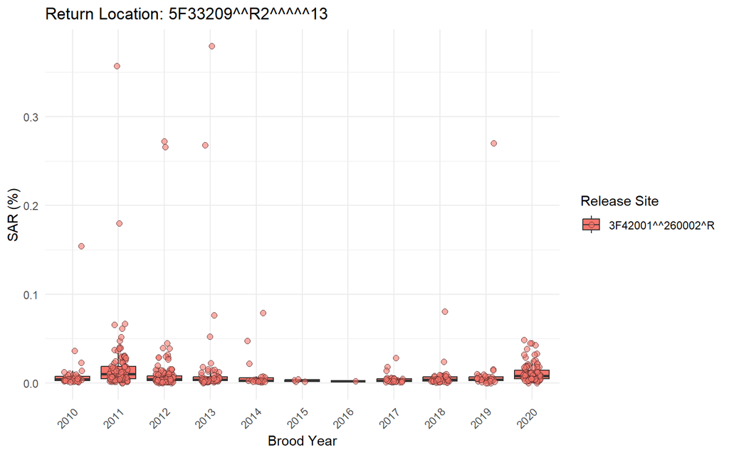

Figure 13: Smolt-adult return calcualted from the raw release and return data across brood years and release sites.

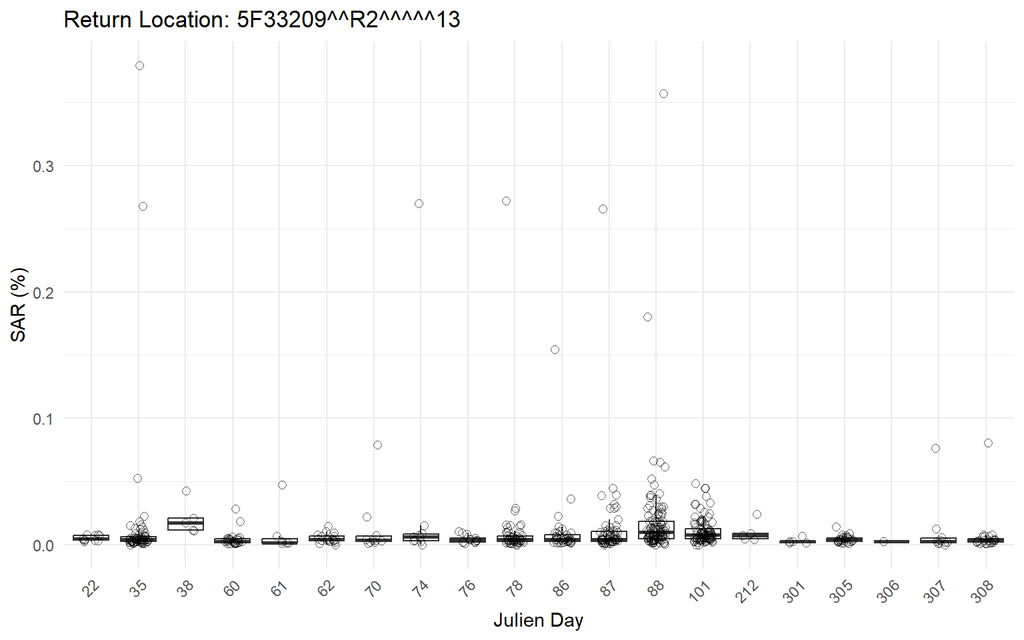

Figure 14: Smolt-adult return calcualted from the raw release and return data across brood years and julian days.

**Tab A**

Table 7: Smolt-adult return calculated across brood years, mean weight-at-release, and time at release.

| species | release_location_code | recovery_location_code | month | jday | avg_weight | event_released | sar |
| --- | --- | --- | --- | --- | --- | --- | --- |
| **2010** |  |  |  |  |  |  |  |
| 1 | 3F42001^^260002^R | 3F42001^^260002^H02 | 3 | 86 | 90 | 83600 | 0.0027159 |
| **2011** |  |  |  |  |  |  |  |
| 1 | 3F42001^^260002^R | 3F42001^^260002^H02 | 3 | 88 | 90 | 69709 | 0.0129807 |
| 1 | 3F42001^^260002^R | 3F42001^^260002^H02 | 3 | 88 | 90 | 31249 | 0.0144545 |
| **2012** |  |  |  |  |  |  |  |
| 1 | 3F42001^^260002^R | 3F42001^^260002^H02 | 3 | 78 | 60 | 98393 | 0.0078878 |
| 1 | 3F42001^^260002^R | 3F42001^^260002^H02 | 3 | 87 | 90 | 95994 | 0.0112051 |
| 1 | 3F42001^^260002^R | 3F42001^^260002^H02 | 11 | 305 | 30 | 99986 | 0.0017630 |
| **2013** |  |  |  |  |  |  |  |
| 1 | 3F42001^^260002^R | 3F42001^^260002^H02 | 2 | 35 | 50 | 94949 | 0.0043151 |
| 1 | 3F42001^^260002^R | 3F42001^^260002^H02 | 2 | 35 | 80 | 95258 | 0.0061065 |
| 1 | 3F42001^^260002^R | 3F42001^^260002^H02 | 11 | 307 | 30 | 92840 | 0.0005111 |
| **2014** |  |  |  |  |  |  |  |
| 1 | 3F42001^^260002^R | 3F42001^^260002^H02 | 3 | 61 | 60 | 96689 | 0.0007484 |
| 1 | 3F42001^^260002^R | 3F42001^^260002^H02 | 3 | 70 | 90 | 96491 | 0.0015711 |
| 1 | 3F42001^^260002^R | 3F42001^^260002^H02 | 10 | 301 | 30 | 98431 | 0.0002651 |
| **2015** |  |  |  |  |  |  |  |
| 1 | 3F42001^^260002^R | 3F42001^^260002^H02 | 3 | 60 | 60 | 99491 | 0.0002017 |
| 1 | 3F42001^^260002^R | 3F42001^^260002^H02 | 3 | 60 | 90 | 96220 | 0.0005341 |
| 1 | 3F42001^^260002^R | 3F42001^^260002^H02 | 10 | 302 | 30 | 93643 | 0.0000644 |
| **2016** |  |  |  |  |  |  |  |
| 1 | 3F42001^^260002^R | 3F42001^^260002^H02 | 3 | 60 | 60 | 96189 | 0.0000532 |
| 1 | 3F42001^^260002^R | 3F42001^^260002^H02 | 3 | 60 | 90 | 94058 | 0.0003039 |
| 1 | 3F42001^^260002^R | 3F42001^^260002^H02 | 11 | 306 | 30 | 82759 | 0.0001241 |
| **2017** |  |  |  |  |  |  |  |
| 1 | 3F42001^^260002^R | 3F42001^^260002^H02 | 3 | 60 | 50 | 94131 | 0.0019507 |
| 1 | 3F42001^^260002^R | 3F42001^^260002^H02 | 3 | 60 | 90 | 99015 | 0.0026588 |
| 1 | 3F42001^^260002^R | 3F42001^^260002^H02 | 6 | 157 | 10 | 60002 | 0.0002742 |
| 1 | 3F42001^^260002^R | 3F42001^^260002^H02 | 11 | 305 | 30 | 100406 | 0.0013764 |
| **2018** |  |  |  |  |  |  |  |
| 1 | 3F42001^^260002^R | 3F42001^^260002^H02 | 1 | 22 | 60 | 53759 | 0.0046400 |
| 1 | 3F42001^^260002^R | 3F42001^^260002^H02 | 3 | 76 | 50 | 99327 | 0.0038275 |
| 1 | 3F42001^^260002^R | 3F42001^^260002^H02 | 7 | 212 | 30 | 57849 | 0.0009896 |
| 1 | 3F42001^^260002^R | 3F42001^^260002^H02 | 11 | 308 | 30 | 49867 | 0.0011727 |
| 1 | 3F42001^^260002^R | 3F42001^^260002^H02 | 11 | 308 | 30 | 51160 | 0.0011196 |
| 1 | 3F42001^^260002^R | 3F42001^^260002^H02 | 11 | 308 | 80 | 144376 | 0.0017348 |
| **2019** |  |  |  |  |  |  |  |
| 1 | 3F42001^^260002^R | 3F42001^^260002^H02 | 3 | 62 | 60 | 99828 | 0.0093619 |
| 1 | 3F42001^^260002^R | 3F42001^^260002^H02 | 3 | 74 | 90 | 95824 | 0.0118885 |
| 1 | 3F42001^^260002^R | 3F42001^^260002^H02 | 11 | 307 | 30 | 101528 | 0.0051414 |
| **2020** |  |  |  |  |  |  |  |
| 1 | 3F42001^^260002^R | 3F42001^^260002^H02 | 2 | 38 | 80 | 22109 | 0.0064128 |
| 1 | 3F42001^^260002^R | 3F42001^^260002^H02 | 4 | 101 | 90 | 40314 | 0.0057573 |
| 1 | 3F42001^^260002^R | 3F42001^^260002^H02 | 4 | 101 | 90 | 49303 | 0.0077886 |
| 1 | 3F42001^^260002^R | 3F42001^^260002^H02 | 4 | 101 | 90 | 45839 | 0.0071880 |
| 1 | 3F42001^^260002^R | 3F42001^^260002^H02 | 4 | 101 | 90 | 48191 | 0.0075971 |
| 1 | 3F42001^^260002^R | 3F42001^^260002^H02 | 4 | 101 | 90 | 49358 | 0.0068451 |
| 1 | 3F42001^^260002^R | 3F42001^^260002^H02 | 4 | 101 | 90 | 49425 | 0.0047652 |
| 1 | 3F42001^^260002^R | 3F42001^^260002^H02 | 4 | 101 | 90 | 49063 | 0.0036932 |
| 1 | 3F42001^^260002^R | 3F42001^^260002^H02 | 4 | 101 | 90 | 49214 | 0.0092086 |
| 1 | 3F42001^^260002^R | 3F42001^^260002^H02 | 4 | 101 | 90 | 48800 | 0.0076510 |
| 1 | 3F42001^^260002^R | 3F42001^^260002^H02 | 4 | 101 | 90 | 49123 | 0.0069955 |
| 1 | 3F42001^^260002^R | 3F42001^^260002^H02 | 4 | 101 | 90 | 49108 | 0.0074067 |
| 1 | 3F42001^^260002^R | 3F42001^^260002^H02 | 4 | 101 | 90 | 49117 | 0.0057296 |

**Tab B**

Table 8: Smolt-adult return calculated across brood years, mean weight-at-release, and time at release.

| species | release_location_code | recovery_location_code | month | jday | avg_weight | event_released | sar |
| --- | --- | --- | --- | --- | --- | --- | --- |
| **2010** |  |  |  |  |  |  |  |
| 1 | 3F42001^^260002^R | 3F42001^^260002^R | 3 | 86 | 90 | 83600 | 0.0002928 |
| **2011** |  |  |  |  |  |  |  |
| 1 | 3F42001^^260002^R | 3F42001^^260002^R | 3 | 88 | 90 | 69709 | 0.0002473 |
| 1 | 3F42001^^260002^R | 3F42001^^270002^R | 3 | 88 | 90 | 69709 | 0.0000584 |
| 1 | 3F42001^^260002^R | 3F42001^^260002^R | 3 | 88 | 90 | 31249 | 0.0001654 |
| **2012** |  |  |  |  |  |  |  |
| 1 | 3F42001^^260002^R | 3F42001^^260002^R | 3 | 78 | 60 | 98393 | 0.0000753 |
| **2013** |  |  |  |  |  |  |  |
| 1 | 3F42001^^260002^R | 3F42001^^260002^R | 2 | 35 | 50 | 94949 | 0.0003795 |
| 1 | 3F42001^^260002^R | 3F42001^^260002^R | 2 | 35 | 80 | 95258 | 0.0001636 |
| **2014** |  |  |  |  |  |  |  |
| 1 | 3F42001^^260002^R | 3F42001^^260002^R | 10 | 301 | 30 | 98431 | 0.0003149 |
| **2018** |  |  |  |  |  |  |  |
| 1 | 3F42001^^260002^R | 3F42001^^260002^R | 3 | 76 | 50 | 99327 | 0.0001063 |
| 1 | 3F42001^^260002^R | 3F42001^^260002^R | 11 | 308 | 80 | 144376 | 0.0000242 |
| **2019** |  |  |  |  |  |  |  |
| 1 | 3F42001^^260002^R | 3F42001^^260002^R | 3 | 74 | 90 | 95824 | 0.0000664 |
| 1 | 3F42001^^260002^R | 3F42001^^260002^R | 11 | 307 | 30 | 101528 | 0.0000626 |
| **2020** |  |  |  |  |  |  |  |
| 1 | 3F42001^^260002^R | 3F42001^^260002^R | 4 | 101 | 90 | 40314 | 0.0001526 |
| 1 | 3F42001^^260002^R | 3F42001^^260002^R | 4 | 101 | 90 | 49303 | 0.0001892 |
| 1 | 3F42001^^260002^R | 3F42001^^260002^R | 4 | 101 | 90 | 45839 | 0.0000694 |
| 1 | 3F42001^^260002^R | 3F42001^^260002^R | 4 | 101 | 90 | 49358 | 0.0000644 |
| 1 | 3F42001^^260002^R | 3F42001^^260002^R | 4 | 101 | 90 | 49425 | 0.0000643 |
| 1 | 3F42001^^260002^R | 3F42001^^260002^R | 4 | 101 | 90 | 49063 | 0.0001902 |
| 1 | 3F42001^^260002^R | 3F42001^^260002^R | 4 | 101 | 90 | 49214 | 0.0001292 |
| 1 | 3F42001^^260002^R | 3F42001^^260002^R | 4 | 101 | 90 | 48800 | 0.0001260 |
| 1 | 3F42001^^260002^R | 3F42001^^260002^R | 4 | 101 | 90 | 49123 | 0.0001252 |
| 1 | 3F42001^^260002^R | 3F42001^^260002^R | 4 | 101 | 90 | 49117 | 0.0000647 |

**Tab C**

Table 9: Smolt-adult return calculated across brood years, mean weight-at-release, and time at release.

| species | release_location_code | recovery_location_code | month | jday | avg_weight | event_released | sar |
| --- | --- | --- | --- | --- | --- | --- | --- |
| **2010** |  |  |  |  |  |  |  |
| 1 | 3F42001^^260002^R | 5F33209^^R2^^^^^13 | 3 | 86 | 90 | 83600 | 0.0001048 |
| 1 | 3F42001^^260002^R | 5F33209^^R3^^^^^13 | 3 | 86 | 90 | 83600 | 0.0000197 |
| 1 | 3F42001^^260002^R | 5F33209^^R4^^^^^13 | 3 | 86 | 90 | 83600 | 0.0000669 |
| 1 | 3F42001^^260002^R | 5F33274^^R74^^^^13 | 3 | 86 | 90 | 83600 | 0.0000388 |
| 1 | 3F42001^^260002^R | 5F33203^^R204^^^12 | 3 | 86 | 90 | 83600 | 0.0000927 |
| 1 | 3F42001^^260002^R | 5F33203^^R205^^^12 | 3 | 86 | 90 | 83600 | 0.0000425 |
| 1 | 3F42001^^260002^R | 3M11105^^872465 | 3 | 86 | 90 | 83600 | 0.0000318 |
| 1 | 3F42001^^260002^R | 3M11105^^872485 | 3 | 86 | 90 | 83600 | 0.0000318 |
| 1 | 3F42001^^260002^R | 5F33201^^R1^^^^^32 | 3 | 86 | 90 | 83600 | 0.0000453 |
| 1 | 3F42001^^260002^R | 3F42001^^260002^R | 3 | 86 | 90 | 83600 | 0.0015434 |
| 1 | 3F42001^^260002^R | 3M21802XX | 3 | 86 | 90 | 83600 | 0.0000135 |
| 1 | 3F42001^^260002^R | 2MN39H001ONEI | 3 | 86 | 90 | 83600 | 0.0000343 |
| 1 | 3F42001^^260002^R | 2MSNGP016QUAR^BY^17 | 3 | 86 | 90 | 83600 | 0.0000609 |
| 1 | 3F42001^^260002^R | 2MSSVP123 | 3 | 86 | 90 | 83600 | 0.0000758 |
| 1 | 3F42001^^260002^R | 2MSSVP123BIG^BK^^08 | 3 | 86 | 90 | 83600 | 0.0002263 |
| 1 | 3F42001^^260002^R | 5M2220202O0202^^11 | 3 | 86 | 90 | 83600 | 0.0000190 |
| 1 | 3F42001^^260002^R | 1M1SE105^10 | 3 | 86 | 90 | 83600 | 0.0000462 |
| 1 | 3F42001^^260002^R | 2MS01P126^^^^^^^000 | 3 | 86 | 90 | 83600 | 0.0000919 |
| 1 | 3F42001^^260002^R | 2MS02M23B^^^^^^^000 | 3 | 86 | 90 | 83600 | 0.0000157 |
| 1 | 3F42001^^260002^R | 3M32202 | 3 | 86 | 90 | 83600 | 0.0000372 |
| 1 | 3F42001^^260002^R | 3M32303 | 3 | 86 | 90 | 83600 | 0.0000409 |
| 1 | 3F42001^^260002^R | 5M2222403O2403^^10 | 3 | 86 | 90 | 83600 | 0.0000126 |
| 1 | 3F42001^^260002^R | 5M2222404O2404^^10 | 3 | 86 | 90 | 83600 | 0.0000185 |
| 1 | 3F42001^^260002^R | 5M2223405O3405^^10 | 3 | 86 | 90 | 83600 | 0.0000462 |
| 1 | 3F42001^^260002^R | 2MS5NM403^^^^^^^000 | 3 | 86 | 90 | 83600 | 0.0000304 |
| 1 | 3F42001^^260002^R | 2MS5NP126^^^^^^^000 | 3 | 86 | 90 | 83600 | 0.0000581 |
| 1 | 3F42001^^260002^R | 2MS5SP024^^^^^^^000 | 3 | 86 | 90 | 83600 | 0.0000604 |
| 1 | 3F42001^^260002^R | 2MS5SP124^^^^^^^000 | 3 | 86 | 90 | 83600 | 0.0000256 |
| 1 | 3F42001^^260002^R | 3M32101 | 3 | 86 | 90 | 83600 | 0.0001244 |

[output cut: 571 more lines]

SAR Model Fit

Smolt-adult survival (SAS) represents the survival of a release group when considering all of their possible fates. The “success” of a program will depend on how well the intended fate of those fish matches up with the observed proportion-at-fate. Here, we take release and return data from above and use these data collectively to calculate SAS as the number of fish that were recovered divided by the number released.

[output not shown]

Signif. codes: 0 <= '***' < 0.001 < '**' < 0.01 < '*' < 0.05  
Adjusted R-squared: 0.936, Deviance explained 0.955  
-REML : -250.580, Scale est: 37.981, N: 68

**Tab 1**

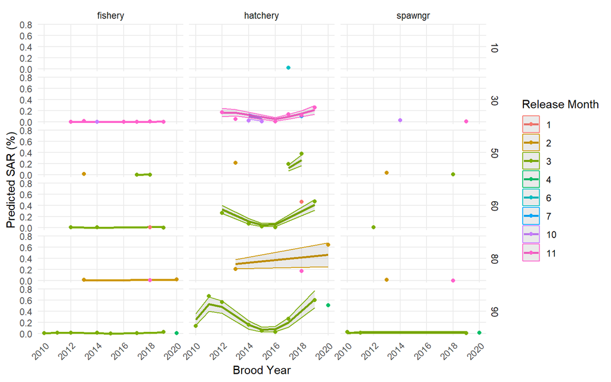

Figure 15: Predicted smolt-adult return generated from the model fit across fate, brood years, mean weight release groups, and release month.

**Tab 2**

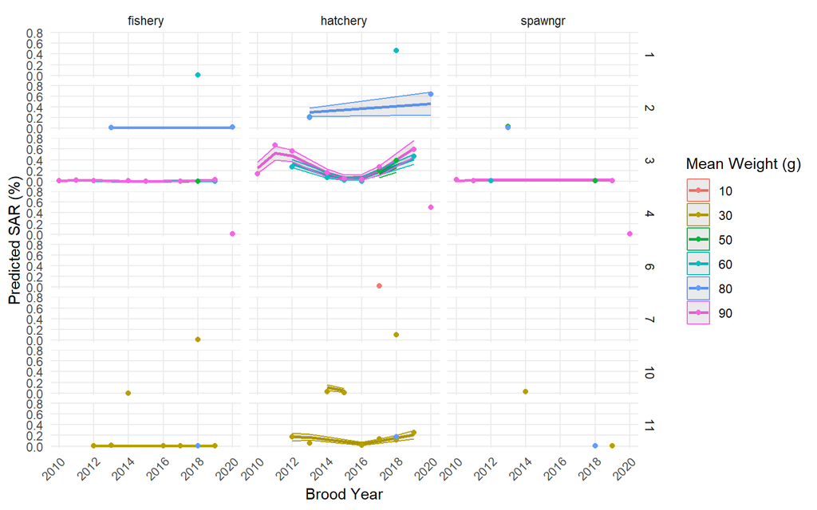

Figure 16: Predicted smolt-adult return generated from the model fit across fate, brood years, mean weight release groups, and release month.

**Tab 3**

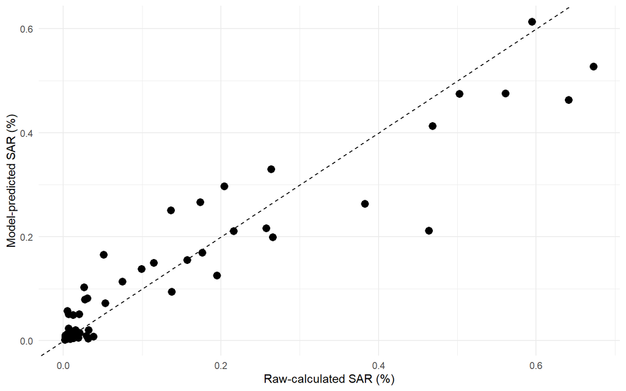

Figure 17: Raw-calculated vs. Model-predicted smolt-adult return generated from the model fit.

**Tab 4**

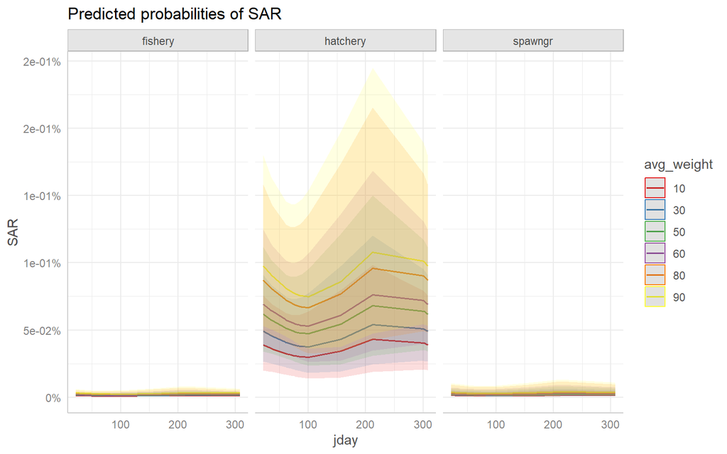

Figure 18: Marginal effects from the model fit showing how combined changes in mean weight at release and release timing (jday) affect smolt-adult-return across fates.

**Tab 1**

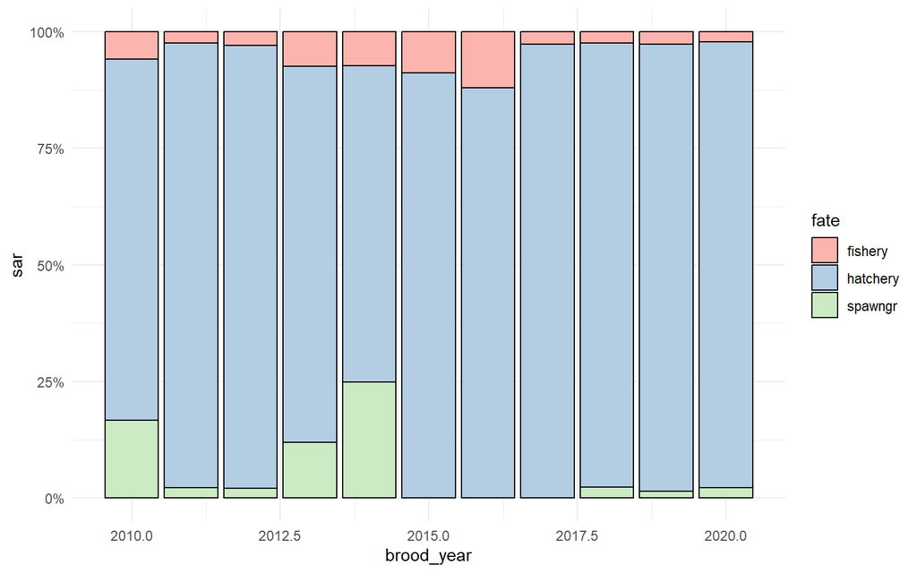

Figure 19: Proportion-at-fate of the calculated smolt-adult-return across brood years.

**Tab 2**

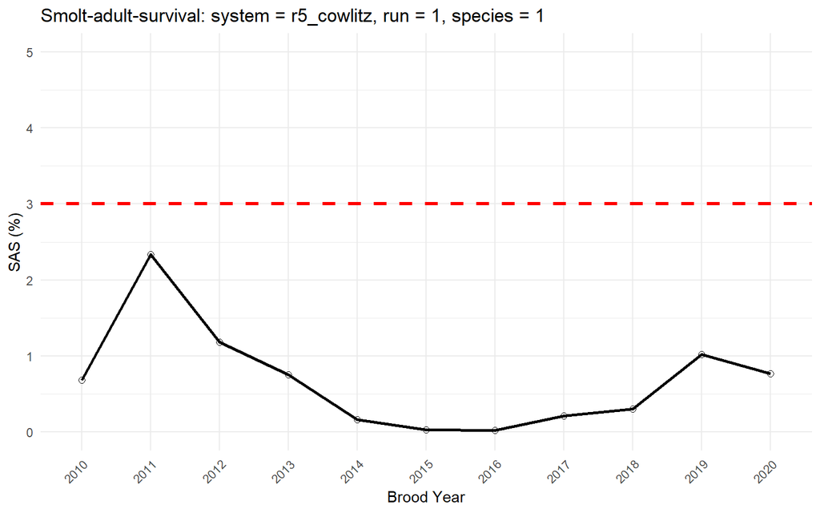

Figure 20: Smolt-adult-survival (SAS) calculated from fate-specific smolt-adult-return relative to a general SAS target for the queried species (red-dashed line).